# 03-ExploratoryDataAnalysis

Carlos Mercado

April 30, 2020

## Lesson 3

The goal of this lesson is to do basic *exploratory data analysis*. This is where you make many basic plots that you wouldn’t show a client. It’s important to do this to find patterns (and errors) that you may need to fix.

Any changes you make to the data should be fully documented and fully reproducible.

Tasks are:

1. Read your data, with strings *not* as factors.
2. remove all rows that contain even a single NA value and call this ‘traffic_no_na’.
3. Subset traffic_no_na data to a new dataset called ‘accidents’ where a row is only kept if there was an accident.
4. Create a histogram for the vehicle year in the accidents dataset. Notice it looks crazy right!

Stretch Task: Can you use the lubridate package to make a new column called “Month of Stop” and make a plot exploring a pattern in the number of accidents in each month?

5. Alter your accident dataset so that any vehicle years prior to 1932 or after 2021 are bottom coded / top coded (i.e. < 1932 becomes 1932 and > 2021 becomes 2021).
6. Re-do steps 4 with your coded vehicle year and add a caption to your plot title saying you’ve re-coded impossible vehicle years. Be careful with your number of breaks. Too few, and the histogram may combine months. I like to make my breaks really big to be safe.

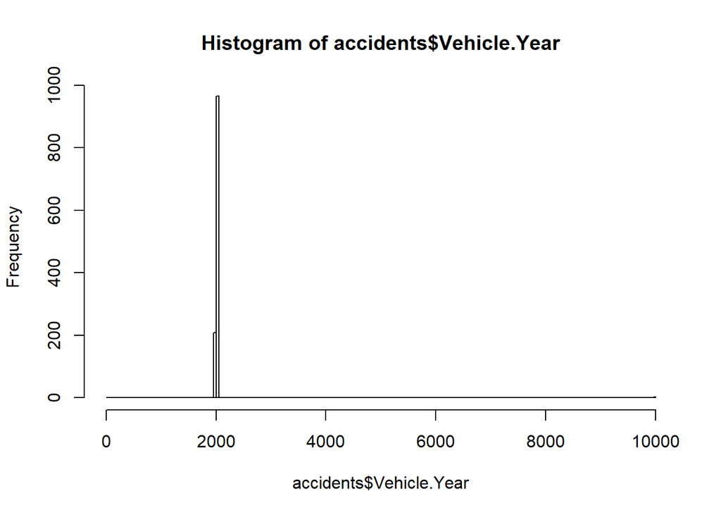

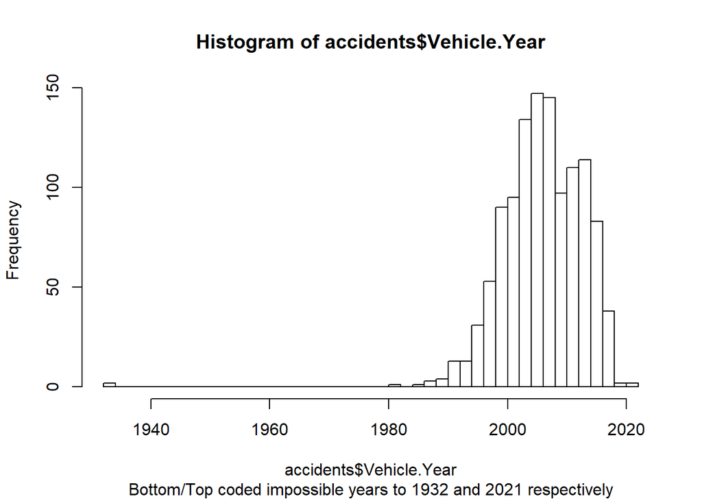

## Stretch task output

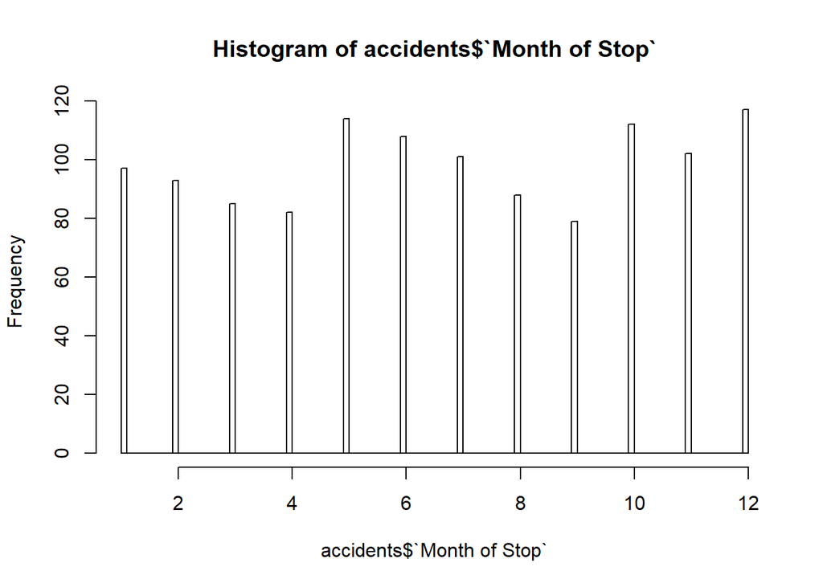

## Test Yourself:

1. How many rows are in traffic_no_na?
2. How many rows are in accidents?
3. How many accidents involved a vehicle from 1999?
4. Which month has the most accidents?

```
## There are 49642 rows in traffic excluding NAs
```

```
## There are 1178 rows in accidents
```

```
## There are 56 accidents with vehicles from 1999
```

```
## There are the most accidents in December
```